# Project Report

Chakravarthy Gajvelly

23 October 2015

## Introduction to the project:

Using devices such as Jawbone Up, Nike FuelBand, and Fitbit it is now possible to collect a large amount of data about personal activity relatively inexpensively. These type of devices are part of the quantified self movement – a group of enthusiasts who take measurements about themselves regularly to improve their health, to find patterns in their behavior, or because they are tech geeks. One thing that people regularly do is quantify how much of a particular activity they do, but they rarely quantify how well they do it.

In this project, we will use data from accelerometers on the belt, forearm, arm, and dumbell of 6 participants and try to predict the manner of how the excercise is done.

## Preprocessing the data

### 1.1 Packages used :

```r
library(ggplot2)
library(caret)
library(randomForest)
library(rpart)
library(rpart.plot)
library(corrplot)
```

### 1.2 Details of the data set used:

The data is taken from the links obtained from the project excercise page and are downloaded and placed in the data folder of the project directory. The .csv files are read locally from this location for conducting this study.

```r
data_train<-read.csv("/home/chakri/Model/data/pml-training.csv")
data_test<-read.csv("/home/chakri/Model/data/pml-testing.csv")
dim(data_train)
```

```
## [1] 19622   160
```

```r
dim(data_test)
```

```
## [1]  20 160
```

The dimensions of the training and test data sets are shown above. Both of them have different number of entries but the common for them is the 160 columns. Training data has 19622 entries(rows) and testing data has 20 entries(rows). Training data has a column “classe”, it is the dependent variable in this case which provides the result of the project.

### 1.3 Cleaning the data

```r
data_train<-data_train[,colSums(is.na(data_train))==0]
data_test<-data_test[,colSums(is.na(data_test))==0]
dim(data_train)
```

```
## [1] 19622    93
```

```r
dim(data_test)
```

```
## [1] 20 60
```

Classe is the predictor in our case which provdies result of the study. Some of the attributes or columns doesnot provide any information or they are useless for the outcome varibale “classe”, they must be removed for obtaining flexible data. Iam using grepl function for this purpose, it matches the string/regular expression in the first argument upon the data given in second argument.

The attributes in the training and testing data are shown below:

```r
names(data_train)
```

```
##  [1] "X"                       "user_name"
##  [3] "raw_timestamp_part_1"    "raw_timestamp_part_2"
##  [5] "cvtd_timestamp"          "new_window"
##  [7] "num_window"              "roll_belt"
##  [9] "pitch_belt"              "yaw_belt"
## [11] "total_accel_belt"        "kurtosis_roll_belt"
## [13] "kurtosis_picth_belt"     "kurtosis_yaw_belt"
## [15] "skewness_roll_belt"      "skewness_roll_belt.1"
## [17] "skewness_yaw_belt"       "max_yaw_belt"
## [19] "min_yaw_belt"            "amplitude_yaw_belt"
## [21] "gyros_belt_x"            "gyros_belt_y"
## [23] "gyros_belt_z"            "accel_belt_x"
## [25] "accel_belt_y"            "accel_belt_z"
## [27] "magnet_belt_x"           "magnet_belt_y"
## [29] "magnet_belt_z"           "roll_arm"
```

[output cut: 32 more lines]

```r
names(data_test)
```

```
##  [1] "X"                    "user_name"            "raw_timestamp_part_1"
##  [4] "raw_timestamp_part_2" "cvtd_timestamp"       "new_window"
##  [7] "num_window"           "roll_belt"            "pitch_belt"
## [10] "yaw_belt"             "total_accel_belt"     "gyros_belt_x"
## [13] "gyros_belt_y"         "gyros_belt_z"         "accel_belt_x"
## [16] "accel_belt_y"         "accel_belt_z"         "magnet_belt_x"
## [19] "magnet_belt_y"        "magnet_belt_z"        "roll_arm"
## [22] "pitch_arm"            "yaw_arm"              "total_accel_arm"
## [25] "gyros_arm_x"          "gyros_arm_y"          "gyros_arm_z"
## [28] "accel_arm_x"          "accel_arm_y"          "accel_arm_z"
## [31] "magnet_arm_x"         "magnet_arm_y"         "magnet_arm_z"
## [34] "roll_dumbbell"        "pitch_dumbbell"       "yaw_dumbbell"
## [37] "total_accel_dumbbell" "gyros_dumbbell_x"     "gyros_dumbbell_y"
## [40] "gyros_dumbbell_z"     "accel_dumbbell_x"     "accel_dumbbell_y"
## [43] "accel_dumbbell_z"     "magnet_dumbbell_x"    "magnet_dumbbell_y"
## [46] "magnet_dumbbell_z"    "roll_forearm"         "pitch_forearm"
## [49] "yaw_forearm"          "total_accel_forearm"  "gyros_forearm_x"
## [52] "gyros_forearm_y"      "gyros_forearm_z"      "accel_forearm_x"
## [55] "accel_forearm_y"      "accel_forearm_z"      "magnet_forearm_x"
## [58] "magnet_forearm_y"     "magnet_forearm_z"     "problem_id"
```

```r
testRemove <- grepl("^X|timestamp|window", names(data_test))
data_test <- data_test[, !testRemove]
testCleaned <- data_test[, sapply(data_test, is.numeric)]
dim(testCleaned)
```

```
## [1] 20 53
```

### 1.4 Data partition for training and testing the model

```r
data_partition <- createDataPartition(train_cleaned$classe, p=0.70, list=F)
model_train <- train_cleaned[data_partition, ]
testData <- train_cleaned[-data_partition, ]
dim(model_train)
```

[output not shown]

```
## [1] 13737    53
```

```r
dim(testData)
```

```
## [1] 5885   53
```

## Creating the model using Random Forests

I have fitted the model using Random Forest algorithm as it preselects the attributes or independent variables that are best for predicting the outcome accurately, its flexibility in correlated covariates and other general factors in decision trees. I have used a 5-fold cross validation before applying the algorithm using trainControl function for controlRf attribute of train method in caret package. The rest of the functionality is shown below

```r
controlRf <- trainControl(method="cv", 5)
controlRf
```

[output not shown]

[output cut: 44 more lines]

[output not shown]

```r
gen_model <- train(classe ~ ., data=model_train, method="rf", trControl=controlRf, ntree=100)
gen_model
```

```
## Random Forest
##
## 13737 samples
##    52 predictors
##     5 classes: 'A', 'B', 'C', 'D', 'E'
##
## No pre-processing
## Resampling: Cross-Validated (5 fold)
## Summary of sample sizes: 10990, 10990, 10988, 10991, 10989
## Resampling results across tuning parameters:
##
##   mtry  Accuracy   Kappa      Accuracy SD  Kappa SD
##    2    0.9889361  0.9860011  0.003549073  0.004493221
##   27    0.9906826  0.9882129  0.001933416  0.002446486
##   52    0.9873343  0.9839767  0.002830500  0.003582982
##
## Accuracy was used to select the optimal model using  the largest value.
## The final value used for the model was mtry = 27.
```

The above output shows the summary of sample sizes which are 5 in number as we chose 5 fold cross validation.

#### 2.1 Predicting the results using the model generated

```r
gen_prediction <- predict(gen_model, testData)
confusionMatrix(testData$classe, gen_prediction)
```

```
## Confusion Matrix and Statistics
##
##           Reference
## Prediction    A    B    C    D    E
##          A 1674    0    0    0    0
##          B   10 1127    2    0    0
##          C    0    8 1017    1    0
##          D    0    1    7  956    0
##          E    0    1    1    2 1078
##
## Overall Statistics
##
##                Accuracy : 0.9944
##                  95% CI : (0.9921, 0.9961)
##     No Information Rate : 0.2862
##     P-Value [Acc > NIR] : < 2.2e-16
##
##                   Kappa : 0.9929
##  Mcnemar's Test P-Value : NA
##
## Statistics by Class:
##
##                      Class: A Class: B Class: C Class: D Class: E
## Sensitivity            0.9941   0.9912   0.9903   0.9969   1.0000
## Specificity            1.0000   0.9975   0.9981   0.9984   0.9992
## Pos Pred Value         1.0000   0.9895   0.9912   0.9917   0.9963
## Neg Pred Value         0.9976   0.9979   0.9979   0.9994   1.0000
## Prevalence             0.2862   0.1932   0.1745   0.1630   0.1832
## Detection Rate         0.2845   0.1915   0.1728   0.1624   0.1832
## Detection Prevalence   0.2845   0.1935   0.1743   0.1638   0.1839
## Balanced Accuracy      0.9970   0.9943   0.9942   0.9976   0.9996
```

In the above output the section “Overall Statistics” has some values for outputs, Accuracy and the out of sample error estimate is shown below.

```r
Accuracy <- postResample(gen_prediction, testData$classe)
Accuracy
```

```
##  Accuracy     Kappa
## 0.9943925 0.9929056
```

```r
out_of_sample_error <- 1 - as.numeric(confusionMatrix(testData$classe, gen_prediction)$overall[1])
out_of_sample_error
```

```
## [1] 0.005607477
```

#### 2.2 Predicting the results of given test data

The model is now used for predicting the “classe” or output of the given test data obtained from the assignment page

```r
result<-predict(gen_model,testCleaned[,-length(names(testCleaned))])
result
```

```
##  [1] B A B A A E D B A A B C B A E E A B B B
## Levels: A B C D E
```

3. Plots:

   3.1 Correlative Matrix Plot

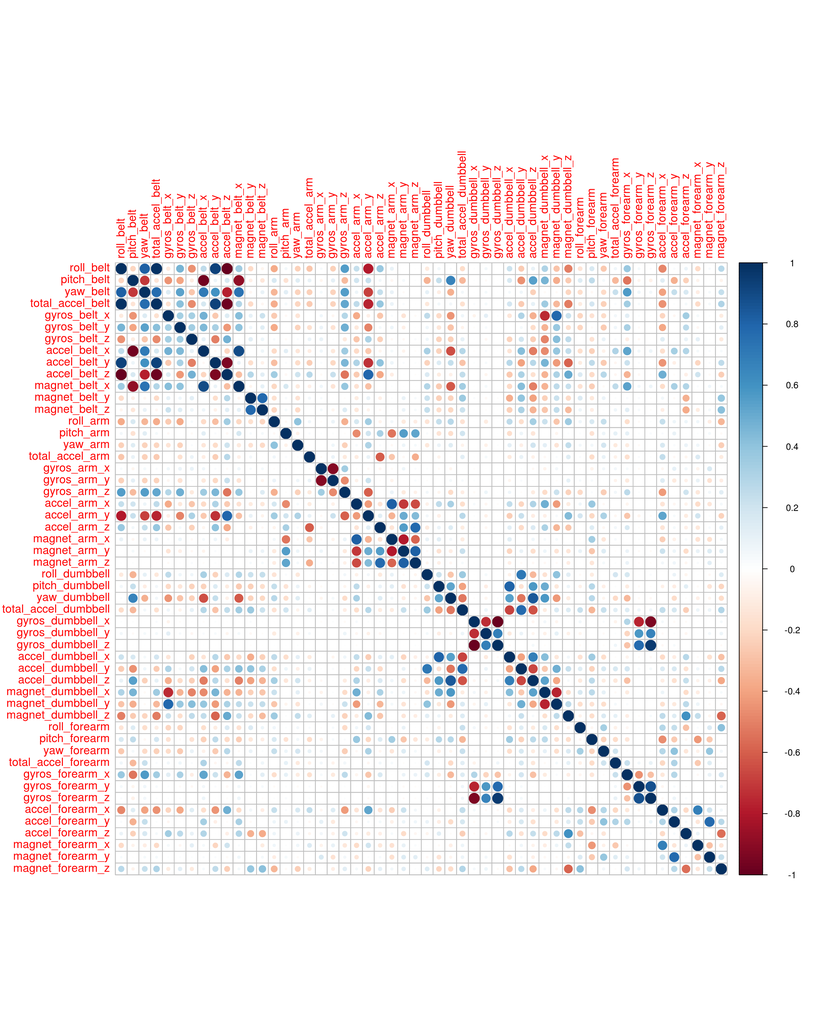

```r
classPlot <- cor(model_train[, -length(names(model_train))])
corrplot(classPlot)
```

3.2 Tree Diagram

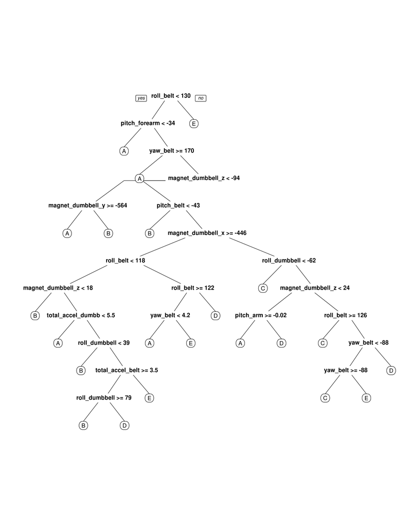

```r
decision_gen_Tree <- rpart(classe ~ ., data=model_train, method="class")
prp(decision_gen_Tree)
```